# Evidencia 1 | Análisis inicial

Olivia Bianelli Navarrete Carrasco-A01654903

```
                             **Primer Avance**
```

**Parte uno**

**1.¿Cuál es la situación actual de COVID-19 a nivel mundial, en México, en tu estado de origen y en tu municipio, alcaldía o colonia?**

A fecha del 17 de abril del 2022, a nivel mundial se confirma un estimado de 503,7 millones de casos nuevos de **COVID-19**, de los cuales Europa puede destacar al contar con alrededor de 206,1 millones de contagio, que hace que supere por 75 millones de casos confirmados a Asia. Por otro lado, Estados Unidos encabeza la lista de pises más afectados, en función del número de casos confirmados por esta pandemia teniendo alrededor de 82,6 millones de casos positivos confirmados.

A nivel nacional, México cuenta con un total de 5.733.785 de casos detectados, y con un estimado de 324.129 de muertes, así como 198.353.262 de vacunas aplicadas a lo largo de todo el país. Por otro lado, en Ciudad de México se puede estimar que existen 1395,445 casos confirmados de COVID-19, a la fecha, con un total de 42,767 muertes, en un contexto más reducido, en la alcaldía Benito Juárez cuenta actualmente con 51,480 casos confirmados y 1,603 defunciones.

**2. ¿Cuál fue la primera variante del virus que se propagó a todo el mundo?** El virus causante de esta enfermedad es el **SARS-COV2**, el cual aparición en China el 31 de diciembre del 2019, el cual dio origen a la actual enfermedad llamada **COVID-19**, la cual rápidamente se extendió por todo el mundo y fue declara por la OMS pandemia mundial. Por otro lado, la variante Alfa fue la primera mutacion del virs SARS-COV2, esta variante es de rapida propagacion.Se detectó por primera vez en el Reino Unido en Diciembre del 2020, la variante B.1.1.7, o también llamada **Alfa**, ha dado la vuelta al mundo convertirse en una de las formas más dominantes de SARS-CoV-2.

**3. ¿Cuáles son las otras variantes del virus que existen en otras regiones del mundo?**

Desde el incio de la pandemia hasta la fecha, existen las siguientes tipos de variantes: -La variante alfa (también conocida como variante Kent o B.1.1.7) que se descubrió por primera vez en el sureste de Inglaterra en septiembre de 2020. -La variante beta (también conocida como variante sudafricana o B.1.351). -La variante gamma (también conocida como variante brasileña o P.2). -La variante delta (también conocida como variante india o P.1).

**4. ¿Cómo buscarías información de la variante del virus en tu país?** Para poder obtener información confiable sobre COVID-19, consultaría la información que el gobierno brinda, proporciona a la población en general, ya que brinda información y estadísticas sobre la situación de todo el país. Así mismo, revisaría artículos confiables de investigación que puedan proporcionarme información relevante sobre este virus.

**5. Imagina que te encuentras en una situación similar a la de Li Wenliang, médico chino que intentó alertar sobre el brote de coronavirus en su país, pero fue detenido por las autoridades y obligado a retractarse, ¿qué harías en su caso? Selecciona un inciso:a) Lo reportas al centro de investigación o la universidad. b) Lo reportas a la prensa. c) Guardas la información.** b) Lo reporto a la prensa Lo reportaría la prensa porque considero sería el medio más rápido para poder propagar información y que de esta forma las sociedades puedan estar conscientes de la situación independientemente de si creen que pueda ser una notica real o no, y por lo menos así podrían prevenirse.

```r
#install.packages("seqinr")
library("seqinr")

sarscov2o <- read.fasta("sarscov2omicron.fasta")
class(sarscov2o)
```

```
## [1] "list"
```

```r
str(sarscov2o)
```

```
## List of 1
##  $ ON188698.1: 'SeqFastadna' chr [1:29730] "t" "a" "g" "a" ...
##   ..- attr(*, "name")= chr "ON188698.1"
##   ..- attr(*, "Annot")= chr ">ON188698.1 Severe acute respiratory syndrome coronavirus 2 isolate SARS-CoV-2/human/USA/UT-UPHL-220331228012/2"| __truncated__
```

```r
#1. ¿Cuál es el tamaño de cada secuencia?
length(sarscov2o[[1]])
```

```
## [1] 29730
```

```r
#2. ¿Cúal es la composición de nucleótidos de cada secuencia?
s<-count(sarscov2o[[1]], 1)
est.x=(s)
print(est.x)
```

```
##
##    a    c    g    t
## 8883 5442 5831 9574
```

```r
table(sarscov2o[[1]])
```

```
##
##    a    c    g    t
## 8883 5442 5831 9574
```

```r
#3. ¿Cuál es el contenido de GC de cada viru?
sars_fasta<-porcentaje(sarscov2o[[1]])
```

```
## [1] "El porcentaje de 'G' es: "
## [1] 19.61319
## [1] "El porcentaje de 'C' es: "
## [1] 18.30474
```

```r
#4. Crea las secuencias contrasentido
 contra<- function(dna){
  dna1<-length(dna)
  inv<-dna[dna1:1]
  return(inv)
 }

contra(sarscov2o[[1]])
```

[output not shown]

[output cut: 34 more lines]

```r
#install.packages("seqinr")
library("seqinr")

sarscov2a <- read.fasta("sarscov2alpha.fasta")
class(sarscov2a)
```

```
## [1] "list"
```

```r
str(sarscov2a)
```

```
## List of 1
##  $ LC654481.1: 'SeqFastadna' chr [1:29848] "a" "t" "t" "a" ...
##   ..- attr(*, "name")= chr "LC654481.1"
##   ..- attr(*, "Annot")= chr ">LC654481.1 Severe acute respiratory syndrome coronavirus 2 KKH094 genomic RNA, complete genome"
```

```r
#1. ¿Cuál es el tamaño de cada secuencia?
length(sarscov2a[[1]])
```

```
## [1] 29848
```

```r
#2. ¿Cúal es la composición de nucleótidos de cada secuencia?
a<-count(sarscov2a[[1]], 1)
est.y=(a)
print(est.y)
```

```
##
##    a    c    g    t
## 8917 5476 5852 9603
```

```r
table(sarscov2a[[1]])
```

```
##
##    a    c    g    t
## 8917 5476 5852 9603
```

```r
#3. ¿Cuál es el contenido de GC de cada viru?
sars_fasta<-porcentaje(sarscov2a[[1]])
```

```
## [1] "El porcentaje de 'G' es: "
## [1] 19.606
## [1] "El porcentaje de 'C' es: "
## [1] 18.34629
```

```r
#4. Crea las secuencias contrasentido
 contra<- function(dna){
  dna1<-length(dna)
  inv<-dna[dna1:1]
  return(inv)
}

contra(sarscov2a[[1]])
```

[output not shown]

[output cut: 34 more lines]

```r
#5Crea una gráfica donde compares las bases de ADN que componen a cada una de las variantes del virus.
```

```r
#install.packages("seqinr")
library("seqinr")

sarscov2b <- read.fasta("sarscov2beta.fasta")
class(sarscov2b)
```

```
## [1] "list"
```

```r
str(sarscov2b)
```

```
## List of 1
##  $ ON322586.1: 'SeqFastadna' chr [1:29767] "t" "t" "g" "t" ...
##   ..- attr(*, "name")= chr "ON322586.1"
##   ..- attr(*, "Annot")= chr ">ON322586.1 Severe acute respiratory syndrome coronavirus 2 isolate SARS-CoV-2/human/SouthAfrica/NHLS-UCT-GS-72"| __truncated__
```

```r
#1. ¿Cuál es el tamaño de cada secuencia?
length(sarscov2b[[1]])
```

```
## [1] 29767
```

```r
#2. ¿Cúal es la composición de nucleótidos de cada secuencia?
b<-count(sarscov2b[[1]], 1)
est.z=(b)
print(est.z)
```

```
##
##    a    c    g    t
## 8888 5457 5842 9580
```

```r
table(sarscov2b[[1]])
```

```
##
##    a    c    g    t
## 8888 5457 5842 9580
```

```r
#3. ¿Cuál es el contenido de GC de cada viru?
sars_fasta<-porcentaje(sarscov2b[[1]])
```

```
## [1] "El porcentaje de 'G' es: "
## [1] 19.62576
## [1] "El porcentaje de 'C' es: "
## [1] 18.33238
```

```r
#4. Crea las secuencias contrasentido
 contra<- function(dna){
  dna1<-length(dna)
  inv<-dna[dna1:1]
  return(inv)
}
contra(sarscov2b[[1]])
```

[output not shown]

[output cut: 34 more lines]

```r
#5Crea una gráfica donde compares las bases de ADN que componen a cada una de las variantes del virus.
```

```r
#install.packages("seqinr")
library("seqinr")

sarscov2d <- read.fasta("sarscov2delta.fasta")
class(sarscov2d)
```

```
## [1] "list"
```

```r
str(sarscov2d)
```

```
## List of 1
##  $ ON316696.1: 'SeqFastadna' chr [1:29861] "a" "a" "c" "c" ...
##   ..- attr(*, "name")= chr "ON316696.1"
##   ..- attr(*, "Annot")= chr ">ON316696.1 Severe acute respiratory syndrome coronavirus 2 isolate SARS-CoV-2/human/USA/CA-SDCPHL-051821-070/2"| __truncated__
```

```r
#1. ¿Cuál es el tamaño de cada secuencia?
length(sarscov2d[[1]])
```

```
## [1] 29861
```

```r
#2. ¿Cúal es la composición de nucleótidos de cada secuencia?
d<-count(sarscov2d[[1]], 1)
est.w=(d)
print(est.w)
```

```
##
##    a    c    g    t
## 8940 5470 5852 9599
```

```r
table(sarscov2d[[1]])
```

```
##
##    a    c    g    t
## 8940 5470 5852 9599
```

```r
#3. ¿Cuál es el contenido de GC de cada viru?
sars_fasta<-porcentaje(sarscov2d[[1]])
```

```
## [1] "El porcentaje de 'G' es: "
## [1] 19.59747
## [1] "El porcentaje de 'C' es: "
## [1] 18.31821
```

```r
#4. Crea las secuencias contrasentido
 contra<- function(dna){
  dna1<-length(dna)
  inv<-dna[dna1:1]
  return(inv)
}
contra(sarscov2d[[1]])
```

[output not shown]

[output cut: 34 more lines]

```r
#5Crea una gráfica donde compares las bases de ADN que componen a cada una de las variantes del virus.
```

```r
#install.packages("seqinr")
library("seqinr")

sarscov2g <- read.fasta("sarscov2gamma.fasta")
class(sarscov2g)
```

```
## [1] "list"
```

```r
str(sarscov2g)
```

```
## List of 1
##  $ ON316567.1: 'SeqFastadna' chr [1:29844] "a" "g" "a" "t" ...
##   ..- attr(*, "name")= chr "ON316567.1"
##   ..- attr(*, "Annot")= chr ">ON316567.1 Severe acute respiratory syndrome coronavirus 2 isolate SARS-CoV-2/human/USA/CA-SDCPHL-042721-280/2"| __truncated__
```

```r
#1. ¿Cuál es el tamaño de cada secuencia?
length(sarscov2g[[1]])
```

```
## [1] 29844
```

```r
#2. ¿Cúal es la composición de nucleótidos de cada secuencia?
g<-count(sarscov2g[[1]], 1)
est.t=(g)
print(est.t)
```

```
##
##    a    c    g    t
## 8939 5470 5850 9584
```

```r
table(sarscov2g[[1]])
```

```
##
##    a    c    g    m    t
## 8939 5470 5850    1 9584
```

```r
#3. ¿Cuál es el contenido de GC de cada viru?
sars_fasta<-porcentaje(sarscov2g[[1]])
```

```
## [1] "El porcentaje de 'G' es: "
## [1] 19.60193
## [1] "El porcentaje de 'C' es: "
## [1] 18.32864
```

```r
#4. Crea las secuencias contrasentido
 contra<- function(dna){
  dna1<-length(dna)
  inv<-dna[dna1:1]
  return(inv)
}
contra(sarscov2g[[1]])
```

[output not shown]

[output cut: 34 more lines]

```r
#5Crea una gráfica donde compares las bases de ADN que componen a cada una de las variantes del virus.
```

```r
porcentaje <- function(dna){
  g1 <- 0
  c1 <- 0

  l <- length(dna)

  for (i in 1:l){
    if (dna[i] == "g"){
      g1 <- g1+1
    }
    else if (dna[i] == "c"){
      c1 <- c1+1
    }
  }

  pg <- g1/l*100
  pc <- c1/l*100


  print("El porcentaje de 'G' es: ")
  print(pg)

  print("El porcentaje de 'C' es: ")
  print(pc)
}

n <- strsplit(dna,split = "")[[1]]


porcentaje(n)
```

```
## [1] "El porcentaje de 'G' es: "
## [1] 50
## [1] "El porcentaje de 'C' es: "
## [1] 50
```

```r
#5Crea una gráfica donde compares las bases de ADN que componen a cada una de las variantes del virus.
```

```r
  # create a dataset
ca<-count(sarscov2o[[1]], 1)
est.x=(ca)
print(est.x)
```

```
##
##    a    c    g    t
## 8883 5442 5831 9574
```

```r
cb<-count(sarscov2a[[1]], 1)
est.y=(cb)
print(est.y)
```

```
##
##    a    c    g    t
## 8917 5476 5852 9603
```

```r
cg<-count(sarscov2b[[1]], 1)
est.z=(cg)
print(est.z)
```

```
##
##    a    c    g    t
## 8888 5457 5842 9580
```

```r
cd<-count(sarscov2d[[1]], 1)
est.w=(cd)
print(est.w)
```

```
##
##    a    c    g    t
## 8940 5470 5852 9599
```

```r
co<-count(sarscov2g[[1]], 1)
est.t=(co)
print(est.t)
```

```
##
##    a    c    g    t
## 8939 5470 5850 9584
```

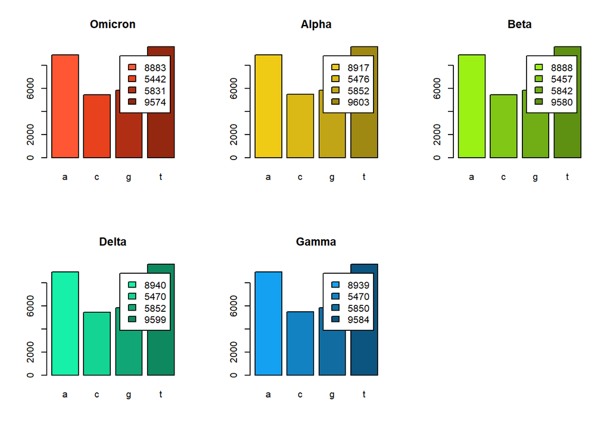

```r
par(mfrow = c(2, 3))

barplot(ca, beside=TRUE, legend=as.factor(unique(est.x)), col = c('#FF5733', '#E8411D','#B02F14','#94270F'), main="Omicron")
barplot(cb, beside=TRUE, legend=as.factor(unique(est.y)), col = c('#F0CB15', '#DAB916','#C2A516','#A08913'), main="Alpha")
barplot(cg, beside=TRUE, legend=as.factor(unique(est.z)), col = c('#9AF113', '#81C716','#71AD15','#5E9012'), main="Beta")
barplot(cd, beside=TRUE, legend=as.factor(unique(est.w)), col = c('#16F0A8', '#14D494','#11A675','#0D885F'), main="Delta")
barplot(co, beside=TRUE, legend=as.factor(unique(est.t)), col = c('#14A1F2',
'#1282C2','#116DA1','#0B5580'), main="Gamma")
```

Como se puede observar en las gráficas anteriores, cada variante tiene una cantidad diferente de nucleótidos en cada secuencia que la conforma. Sin embargo, se puede observar que todas las variantes tienen una mayor cantidad de timina y adenina en comparación con citocina y guanina. Así mismo, podemos observar que todas las variables tiene una longitud de hebra aproximadamente similar, lo que consistente considerando que todas cuentan con el mismo virus de origen.

**Referencias**

Centros para el Control y la Prevención de Enfermedades. (2021). Clasificaciones y definiciones de las variantes del SARS-CoV-2. 25 de Abril del 2022, de Centros para el Control y la Prevención de Enfermedades Sitio web: https://espanol.cdc.gov/coronavirus/2019-ncov/variants/variant-classifications.html

Gobierno de México . (2022). Covid-19 CDMX. 25 de Abril del 2022, de Gobierno de México Sitio web: https://cdmx.dash.covid19.geoint.mx/

Johns Hopkins University & Medicine . (2021). COVID-19 Dashboard. 25 de abril del 2022, de Johns Hopkins University & Medicine Sitio web: https://coronavirus.jhu.edu/map.html

Abigail Orús. (2022). Número de casos confirmados de coronavirus a nivel mundial a fecha de 17 de abril de 2022, por continente. 25 de abril del 2022, de statista Sitio web: https://es.statista.com/estadisticas/1107712/covid19-casos-confirmados-a-nivel-mundial-por-region/

Abigail Orús . (2022). Número de casos confirmados de coronavirus en el mundo a fecha de 22 de abril de 2022, por país. 25 de abril del 2022, de statista Sitio web: https://es.statista.com/estadisticas/1091192/paises-afectados-por-el-coronavirus-de-wuhan-segun-los-casos-confirmados/